# DCM analysis

Kenny Smith and Jennifer Culbertson

29/11/2023

# Load the data.

```r
#load data
data <- read.csv('RawData/rawdata.csv')

#set everything to factors
data$Day <- as.factor(data$Day)
data$Experiment<-as.factor(data$Experiment)
data$Animacy <- as.factor(data$Animacy)
data$WordOrder <- as.factor(data$WordOrder)
data$ProportionMarked <- as.factor(data$ProportionMarked)
#force 40% as reference level
data$ProportionMarked <- relevel(data$ProportionMarked,ref="40% Casemarked")
#force OSV as reference level
data$MajorityInputOrder <- as.factor(data$MajorityInputOrder)
data$MajorityInputOrder <- relevel(data$MajorityInputOrder,ref="OSV majority order")
data$OrderMarkedMore <- as.factor(data$OrderMarkedMore)
data$OrderMarkedMore <- relevel(data$OrderMarkedMore,ref="OSV marked more")


#at some point we switched terminology in the paper from Agents Can/Cannot be Patients to Subjects Can/Cannot Be Objects - need to correct this throughout
data$EventType <- revalue(data$EventType,
                              c("Agents Cannot Be Patients"="Subjects Cannot Be Objects",
                                "Agents Can Be Patients"="Subjects Can Be Objects"))

#Subjects Cannot Be Objects needs to be reference level
data$EventType <- as.factor(data$EventType)
data$EventType <- relevel(data$EventType,
                                        ref="Subjects Cannot Be Objects")
```

# Counts of participants and participant exclusions per day

```r
#got this from https://stackoverflow.com/questions/12840294/counting-unique-distinct-values-by-group-in-a-data-frame
counts.table <- ddply(data,~Day,summarise,N=length(unique(workerId)))
counts.table
```

```
##   Day   N
## 1   1 522
## 2   2 404
## 3   3 375
## 4   4 341
```

```r
scores.by.block <- aggregate(score~workerId+Day+Block,data=data,FUN=mean)

failed.noun.comprehension <- subset(scores.by.block,Block=='NounComprehension2' & score<0.7)
ddply(failed.noun.comprehension,~Day,summarise,N_excluded=length(unique(workerId)))
```

```
##   Day N_excluded
## 1   1         12
```

```r
failed.sentence.comprehension <- subset(scores.by.block,Block=='SentenceComprehension1' & score<0.7)
ddply(failed.sentence.comprehension,~Day,summarise,N_excluded=length(unique(workerId)))
```

```
##   Day N_excluded
## 1   1         25
## 2   2          2
## 3   3          2
```

# Removing excluded participants

In the interests of simplicity, removing all participants who don’t complete all 4 days, so we have a sample of 341 throughout.

```r
day4_participants <- unique(subset(scores.by.block,Day==4)$workerId)
data <- subset(data,workerId %in% day4_participants)
```

# Counts of grammatical/ungrammatical trials

Including these so we can see how they were calculated.

```r
aggregate(grammatical~Day,FUN=mean,data=subset(data,Block=="SentenceTest1"))
```

```
##   Day grammatical
## 1   2   0.6962881
## 2   3   0.8145656
## 3   4   0.8468236
```

```r
rejection.counts <- ddply(subset(data,Block=="SentenceTest1" & grammatical==0),~wordorder,summarise,N=length(unique(workerId)))
#ordered list of rejection types, if you want to see it - quite long
rejection.counts <- rejection.counts[order(-rejection.counts$N),]
```

## Identification accuracy on comprehension trials

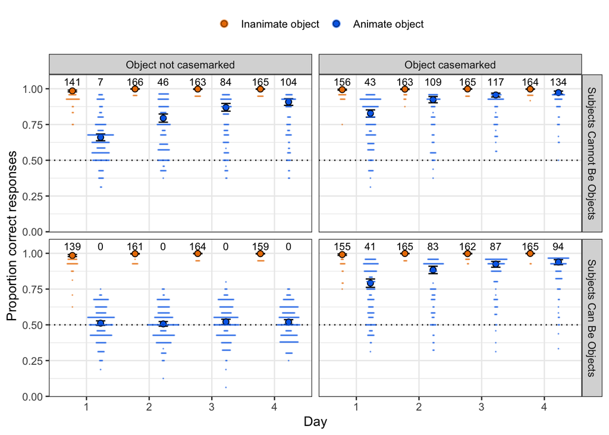

Contrast coding for analysis - dummy code for casemarked, Day, EventType, so that intercept indicates unmarked, day 1, Subjects Cannot Be Objects. Deviation code ProportionMarked and MajorityInputOrder.

```r
#dummy code casemarked, Day, EventType - intercept indicates unmarked, day 1, Subjects Cannot Be Objects
contrasts(data$casemarked) <- NULL
contrasts(data$Day) <- NULL
contrasts(data$EventType) <- NULL

#deviation coding for ProportionMarked: + = 60% casemarked
contrasts(data$ProportionMarked) <- c(-0.5,0.5)
#deviation coding for MajorityInputOrder: + = SOV majority order
contrasts(data$MajorityInputOrder) <- c(-0.5,0.5)
```

For main text, just running simpler models where we exclude the language factors.

```r
#this takes amazingly long but converges
score.model.full <- glmer(score~casemarked * Day * EventType + (1 + casemarked*Day | workerId),data=subset(data,Block=="SentenceComprehension1" & Animacy==TRUE),family=binomial,control=glmerControl(optimizer="bobyqa",optCtrl=list(maxfun=50000)))
```

```
## boundary (singular) fit: see help('isSingular')
```

```r
summary(score.model.full)
```

```
## Generalized linear mixed model fit by maximum likelihood (Laplace Approximation) ['glmerMod']
##  Family: binomial  ( logit )
## Formula: score ~ casemarked * Day * EventType + (1 + casemarked * Day |      workerId)
##    Data: subset(data, Block == "SentenceComprehension1" & Animacy == TRUE)
## Control: glmerControl(optimizer = "bobyqa", optCtrl = list(maxfun = 50000))
##
##      AIC      BIC   logLik deviance df.resid
##  42635.5  43098.6 -21265.8  42531.5    54393
##
## Scaled residuals:
##      Min       1Q   Median       3Q      Max
## -13.4035   0.0482   0.1677   0.4941   1.6224
##
## Random effects:
##  Groups   Name                Variance Std.Dev. Corr
##  workerId (Intercept)         0.1603   0.4004
##           casemarkedTRUE      1.8816   1.3717   -0.08
##           Day2                0.2815   0.5306    0.70  0.21
##           Day3                0.8944   0.9457    0.57  0.19  0.97
##           Day4                1.0545   1.0269    0.53  0.23  0.91  0.98
##           casemarkedTRUE:Day2 1.0914   1.0447   -0.01  0.28  0.19  0.13  0.06
##           casemarkedTRUE:Day3 1.7019   1.3046   -0.20 -0.29 -0.38 -0.33 -0.29  0.55
##           casemarkedTRUE:Day4 2.8576   1.6905   -0.30 -0.44 -0.36 -0.33 -0.35  0.48  0.79
## Number of obs: 54445, groups:  workerId, 341
##
## Fixed effects:
##                                                      Estimate Std. Error z value Pr(>|z|)
## (Intercept)                                           0.72847    0.04857  14.998  < 2e-16 ***
## casemarkedTRUE                                        1.40261    0.12811  10.949  < 2e-16 ***
## Day2                                                  0.97201    0.07865  12.359  < 2e-16 ***
## Day3                                                  2.04449    0.12480  16.381  < 2e-16 ***
## Day4                                                  2.62790    0.14745  17.823  < 2e-16 ***
## EventTypeSubjects Can Be Objects                     -0.66513    0.06759  -9.841  < 2e-16 ***
## casemarkedTRUE:Day2                                   1.24356    0.19814   6.276 3.47e-10 ***
## casemarkedTRUE:Day3                                   0.51989    0.23427   2.219   0.0265 *
## casemarkedTRUE:Day4                                   0.46926    0.28219   1.663   0.0963 .
## casemarkedTRUE:EventTypeSubjects Can Be Objects       0.35791    0.17594   2.034   0.0419 *
## Day2:EventTypeSubjects Can Be Objects                -1.00595    0.10204  -9.859  < 2e-16 ***
## Day3:EventTypeSubjects Can Be Objects                -2.02220    0.15320 -13.199  < 2e-16 ***
## Day4:EventTypeSubjects Can Be Objects                -2.60765    0.17502 -14.899  < 2e-16 ***
## casemarkedTRUE:Day2:EventTypeSubjects Can Be Objects  0.25957    0.22042   1.178   0.2390
## casemarkedTRUE:Day3:EventTypeSubjects Can Be Objects  1.16415    0.26448   4.402 1.07e-05 ***
## casemarkedTRUE:Day4:EventTypeSubjects Can Be Objects  1.50831    0.31837   4.738 2.16e-06 ***
## ---
## Signif. codes:  0 '***' 0.001 '**' 0.01 '*' 0.05 '.' 0.1 ' ' 1
```

```
##
## Correlation matrix not shown by default, as p = 16 > 12.
## Use print(x, correlation=TRUE)  or
##     vcov(x)        if you need it
```

```
## optimizer (bobyqa) convergence code: 0 (OK)
## boundary (singular) fit: see help('isSingular')
```

Performance at the intercept is significantly above 50%, and indeed significantly higher than if participants made optimal use of word order cues to agency, 60% of sentences used the majority order, which would yield an expected log odds of success for an attentive learner of:

```r
prob2logit(0.6)
```

```
## [1] 0.4054651
```

, which is significantly lower than the success rates of our participants:

```r
my.logodds.p(0.6,score.model.full,"(Intercept)")
```

```
## [1] 2.929443e-11
```

Plot split by input language (for supporting information). For this we are just looking at unmarked animates, so I am using two shades of blue.

```r
score.summary.by.lang <- aggregate(score~ProportionMarked+MajorityInputOrder+casemarked+Animacy+Day+EventType+workerId,data=subset(data,Block=="SentenceComprehension1"),FUN=mean)
score.summary.by.lang$casemarked <- revalue(as.factor(score.summary.by.lang$casemarked),
                                    c("FALSE"="Object not casemarked",
                                      "TRUE"="Object casemarked"))

#for the dotplot, there are too many participants at ceiling to show the dots - instead I am going to withhold those dots and add a numerical annotation
score.summary.by.lang$IsPerfect <- ifelse(score.summary.by.lang$score==1,1,0)
score.summary.by.lang.perfect.ns <- data.frame(summarise(group_by(subset(score.summary.by.lang,IsPerfect==1),ProportionMarked,MajorityInputOrder,Day,Animacy,casemarked,EventType),n()))
score.summary.by.lang.perfect.ns <- plyr::rename(score.summary.by.lang.perfect.ns,c("n.."="count"))
#manually adding 0 counts!
score.summary.by.lang.perfect.ns <- tidyr::complete(score.summary.by.lang.perfect.ns,ProportionMarked,MajorityInputOrder,Day,Animacy,casemarked,EventType,fill=list(count=0))
```

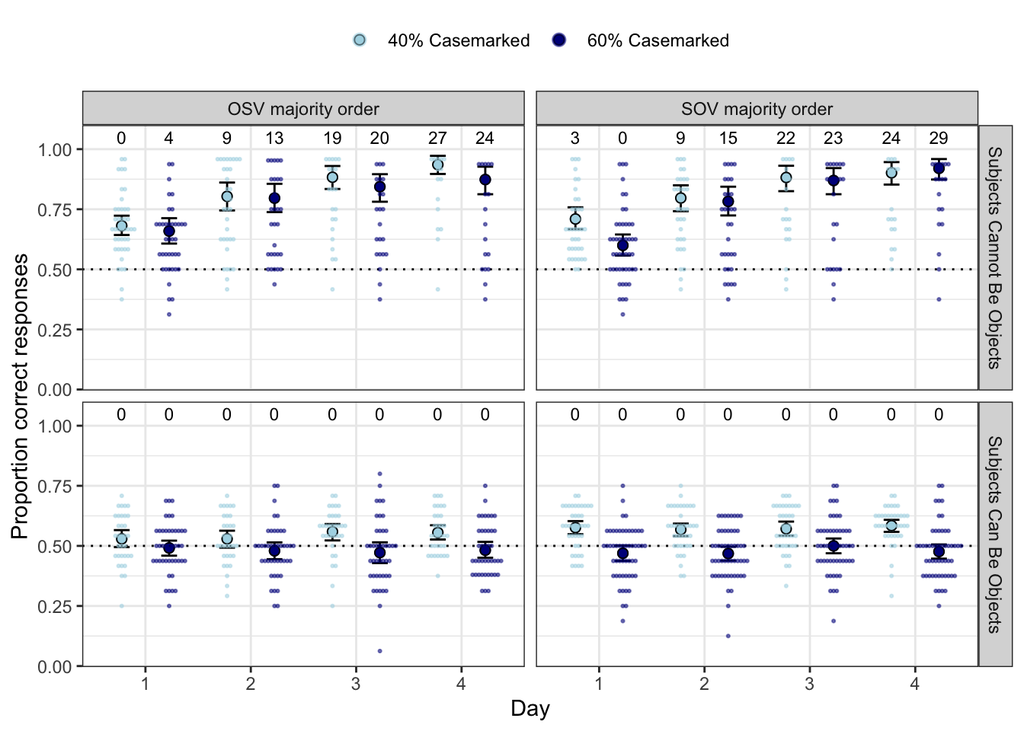

```r
ggplot(data=subset(score.summary.by.lang,Animacy==TRUE & casemarked=="Object not casemarked"), aes(x=Day, y=score, fill=ProportionMarked,colour=ProportionMarked)) +
  #facet by condition and marking
  facet_grid(EventType~MajorityInputOrder) +
  #bars and CIs for score by animacy
  stat_summary(geom='errorbar', fun.data='mean_cl_boot',fun.min="min", fun.max="max",width=0.3,position=position_dodge(0.9),colour='black') +
  stat_summary(geom='point', fun='mean', position=position_dodge(0.9),size=2) +
  stat_summary(geom='point', fun='mean', position=position_dodge(0.9),size=2,shape=1,colour='black') +
  #horizontal line showing chance
  geom_hline(yintercept=0.5,linetype=3) +
geom_dotplot(data=subset(score.summary.by.lang,IsPerfect==0 & Animacy==TRUE & casemarked=="Object not casemarked"),
                aes(x=Day, y=score, fill=ProportionMarked),
               binaxis = "y",
                stackdir = "centerwhole",stackratio=1,alpha=0.5,dotsize=0.4,
                position=position_dodge(0.9),#binpositions='all',binwidth=1/100
               ) +
  #add counts of perfect as text
  geom_text(data=subset(score.summary.by.lang.perfect.ns,Animacy==TRUE & casemarked=="Object not casemarked" & !is.na(MajorityInputOrder)),aes(x=Day,y=1.05,label=count),position=position_dodge(0.9),size=3,colour='black') +
  #then various axis/legend stuff
  xlab("Day") +
  theme_bw() +
  scale_y_continuous(name="Proportion correct responses",breaks=seq(0,1,0.25)) +
  theme(legend.title=element_blank(),legend.position="top") +
  scale_fill_manual(values=c('lightblue','darkblue')) +
  scale_colour_manual(values=c('lightblue','darkblue'))
```

```r
ggsave("Figures/identification-accuracy-by-lang.pdf",width=9, height=9)
```

In the interests of interpretability, just running the most complex stat on unmarked animates, since these are the interesting ones! In addition to the expected effects, looks like:

40% marked languages do a bit better on day 1 (as indicated by negative effect of ProportionMarked). This advantage is missing at day 2 (as indicated by a + ProportionMarked:Day interaction), but since that interaction is only present in day 2 I am not sure it’s very meaningful.

So in sum, probably the only interesting result here is that the participants with less frequent casemarking do a little better on *unmarked* nouns across the board, suggesting they are more attentive to the word order cue.

```r
score.model.bylang.1 <- glmer(score~Day * EventType * ProportionMarked * MajorityInputOrder + (1 + Day | workerId),data=subset(data,Block=="SentenceComprehension1" & Animacy==TRUE & casemarked==FALSE),family=binomial,control=glmerControl(optimizer="bobyqa",optCtrl=list(maxfun=50000)))
```

```
## boundary (singular) fit: see help('isSingular')
```

Model 1 is singular, trying uncorrelated intercepts and slopes.

```r
score.model.bylang.2 <- glmer(score~Day * EventType * ProportionMarked * MajorityInputOrder + (1 | workerId) + (0 + Day | workerId),data=subset(data,Block=="SentenceComprehension1" & Animacy==TRUE & casemarked==FALSE),family=binomial,control=glmerControl(optimizer="bobyqa",optCtrl=list(maxfun=50000)))
```

```
## boundary (singular) fit: see help('isSingular')
```

Model 2 also singular, so forced to use the most simple one.

```r
score.model.bylang.simple <- glmer(score~Day * EventType * ProportionMarked * MajorityInputOrder + (1 | workerId),data=subset(data,Block=="SentenceComprehension1" & Animacy==TRUE & casemarked==FALSE),family=binomial,control=glmerControl(optimizer="bobyqa",optCtrl=list(maxfun=50000)))
```

```r
summary(score.model.bylang.simple)
```

```
## Generalized linear mixed model fit by maximum likelihood (Laplace Approximation) ['glmerMod']
##  Family: binomial  ( logit )
## Formula: score ~ Day * EventType * ProportionMarked * MajorityInputOrder +      (1 | workerId)
##    Data: subset(data, Block == "SentenceComprehension1" & Animacy == TRUE &      casemarked == FALSE)
## Control: glmerControl(optimizer = "bobyqa", optCtrl = list(maxfun = 50000))
##
##      AIC      BIC   logLik deviance df.resid
##  29555.6  29826.1 -14744.8  29489.6    26726
##
## Scaled residuals:
##     Min      1Q  Median      3Q     Max
## -7.2477 -0.9498  0.3148  0.7956  1.7727
##
## Random effects:
##  Groups   Name        Variance Std.Dev.
##  workerId (Intercept) 0.4647   0.6817
## Number of obs: 26759, groups:  workerId, 341
##
## Fixed effects:
##                                                                              Estimate Std. Error z value Pr(>|z|)
## (Intercept)                                                                  0.809282   0.066122  12.239  < 2e-16 ***
## Day2                                                                         0.778278   0.060653  12.832  < 2e-16 ***
## Day3                                                                         1.384072   0.067534  20.494  < 2e-16 ***
## Day4                                                                         1.830243   0.074918  24.430  < 2e-16 ***
## EventTypeSubjects Can Be Objects                                            -0.741887   0.092014  -8.063 7.46e-16 ***
## ProportionMarked1                                                           -0.359606   0.131525  -2.734 0.006255 **
## MajorityInputOrder1                                                         -0.060520   0.131513  -0.460 0.645384
## Day2:EventTypeSubjects Can Be Objects                                       -0.800145   0.078847 -10.148  < 2e-16 ***
## Day3:EventTypeSubjects Can Be Objects                                       -1.347014   0.084272 -15.984  < 2e-16 ***
## Day4:EventTypeSubjects Can Be Objects                                       -1.793329   0.090395 -19.839  < 2e-16 ***
## Day2:ProportionMarked1                                                       0.275032   0.120910   2.275 0.022925 *
## Day3:ProportionMarked1                                                       0.073904   0.134432   0.550 0.582492
## Day4:ProportionMarked1                                                       0.071503   0.149088   0.480 0.631509
## EventTypeSubjects Can Be Objects:ProportionMarked1                           0.063276   0.183339   0.345 0.729996
## Day2:MajorityInputOrder1                                                    -0.001741   0.120891  -0.014 0.988508
## Day3:MajorityInputOrder1                                                     0.171199   0.134420   1.274 0.202801
## Day4:MajorityInputOrder1                                                     0.093135   0.149081   0.625 0.532150
## EventTypeSubjects Can Be Objects:MajorityInputOrder1                         0.112918   0.183331   0.616 0.537947
## ProportionMarked1:MajorityInputOrder1                                       -0.537591   0.261143  -2.059 0.039532 *
## Day2:EventTypeSubjects Can Be Objects:ProportionMarked1                     -0.284005   0.157246  -1.806 0.070900 .
## Day3:EventTypeSubjects Can Be Objects:ProportionMarked1                     -0.102693   0.167914  -0.612 0.540817
## Day4:EventTypeSubjects Can Be Objects:ProportionMarked1                     -0.141610   0.180095  -0.786 0.431687
## Day2:EventTypeSubjects Can Be Objects:MajorityInputOrder1                    0.005874   0.157232   0.037 0.970197
## Day3:EventTypeSubjects Can Be Objects:MajorityInputOrder1                   -0.141535   0.167904  -0.843 0.399255
## Day4:EventTypeSubjects Can Be Objects:MajorityInputOrder1                   -0.103000   0.180089  -0.572 0.567363
## Day2:ProportionMarked1:MajorityInputOrder1                                   0.381897   0.240137   1.590 0.111760
## Day3:ProportionMarked1:MajorityInputOrder1                                   0.664240   0.266663   2.491 0.012741 *
## Day4:ProportionMarked1:MajorityInputOrder1                                   1.427020   0.295563   4.828 1.38e-06 ***
## EventTypeSubjects Can Be Objects:ProportionMarked1:MajorityInputOrder1       0.252864   0.363815   0.695 0.487034
## Day2:EventTypeSubjects Can Be Objects:ProportionMarked1:MajorityInputOrder1 -0.304113   0.312273  -0.974 0.330122
## Day3:EventTypeSubjects Can Be Objects:ProportionMarked1:MajorityInputOrder1 -0.312117   0.333270  -0.937 0.349002
## Day4:EventTypeSubjects Can Be Objects:ProportionMarked1:MajorityInputOrder1 -1.298644   0.356902  -3.639 0.000274 ***
## ---
## Signif. codes:  0 '***' 0.001 '**' 0.01 '*' 0.05 '.' 0.1 ' ' 1
```

```
##
## Correlation matrix not shown by default, as p = 32 > 12.
## Use print(x, correlation=TRUE)  or
##     vcov(x)        if you need it
```

# Word order and animacy

Want to check for more frequent use of SOV with inanimate objects (= higher use of OSV with animate objects).

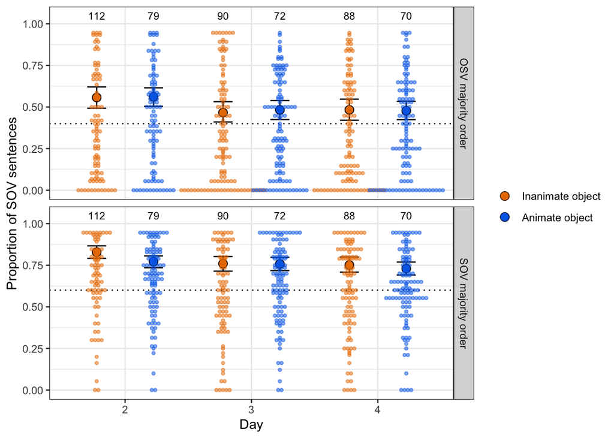

```r
sov.summary.by.animacy <- aggregate(isSOV~Animacy+Day+MajorityInputOrder+ProportionMarked+workerId,data=subset(data,Block=="SentenceTest1" & grammatical),FUN=mean)

#for the collapsed dotplot, there are too many participants at ceiling to show the dots - instead I am going
#to withhold those dots and add a numerical annotation
sov.summary.by.animacy$IsPerfect <- ifelse(sov.summary.by.animacy$isSOV==1,1,0)
sov.summary.by.animacy$Day <- droplevels(sov.summary.by.animacy$Day)
allsov.ns <- data.frame(summarize(group_by(subset(sov.summary.by.animacy,IsPerfect==1 & Day!=1),Day,Animacy,.drop = FALSE),n()))
allsov.ns <- plyr::rename(allsov.ns,c("n.."="count"))

#Input levels
word.order.inputs <- data.frame(MajorityInputOrder=c("SOV majority order","OSV majority order"),
                          isSOV=c(0.6,0.4))






ggplot(data=sov.summary.by.animacy, aes(x=Day, y=isSOV, fill=Animacy,colour=Animacy)) +
  facet_grid(MajorityInputOrder~.) +
  #points and CIs for word order by animacy
  stat_summary(geom='errorbar', fun.data='mean_cl_boot',fun.min="min", fun.max="max",width=0.3,position=position_dodge(0.9),color='black') +
  stat_summary(geom='point', fun='mean', position=position_dodge(0.9), size=3) +
  stat_summary(geom='point', fun='mean', position=position_dodge(0.9), size=3, shape=1, colour='black') +


  #horizontal lines showing input
  geom_hline(data=word.order.inputs, aes(yintercept=isSOV),linetype=3) +


  #by-participant data
  geom_dotplot(data=subset(sov.summary.by.animacy,IsPerfect!=1),binaxis = "y", stackdir = "center",alpha=0.5,dotsize=2,position=position_dodge(0.9),binpositions='all',binwidth=1/100) +
  geom_text(data=allsov.ns,aes(x=Day,y=1.05,label=count),position=position_dodge(0.9),size=3,colour='black') +

  #then various axis/legend stuff
  xlab("Day") +
  theme_bw() +
  theme(legend.title=element_blank()) +
  scale_y_continuous(name="Proportion of SOV sentences",breaks=seq(0,1,0.25)) +

  scale_colour_manual(values=my.colours[2:3],breaks=c("FALSE", "TRUE"),labels=c("Inanimate object", "Animate object")) +
  scale_fill_manual(values=my.colours[2:3],breaks=c("FALSE", "TRUE"),labels=c("Inanimate object", "Animate object"))
```

```r
ggsave("Figures/wordorder-collapsed.pdf",width=9, height=4.5)
```

Stat - primary question is whether animacy affects word order, but including MajorityInputOrder here since that should affect proportion of SOV use!

Contrast coding for analysis - dummy code for Day and MajorityInputOrder, so that intercept indicates day 2, OSV input. Deviation code animacy.

```r
contrasts(data$Day) <- NULL
contrasts(data$MajorityInputOrder) <- NULL
contrasts(data$Animacy) <- c(-0.5,0.5)
```

```r
sovorder.model.1 <- glmer(isSOV ~ Animacy * Day * MajorityInputOrder  + (1 + Animacy * Day | workerId),data=subset(data,Block=="SentenceTest1" & grammatical),family=binomial,control=glmerControl(optimizer="bobyqa",optCtrl=list(maxfun=50000)))
```

```r
summary(sovorder.model.1)
```

```
## Generalized linear mixed model fit by maximum likelihood (Laplace Approximation) ['glmerMod']
##  Family: binomial  ( logit )
## Formula: isSOV ~ Animacy * Day * MajorityInputOrder + (1 + Animacy * Day |      workerId)
##    Data: subset(data, Block == "SentenceTest1" & grammatical)
## Control: glmerControl(optimizer = "bobyqa", optCtrl = list(maxfun = 50000))
##
##      AIC      BIC   logLik deviance df.resid
##  26433.5  26709.8 -13183.7  26367.5    31934
##
## Scaled residuals:
##     Min      1Q  Median      3Q     Max
## -8.0488 -0.3807  0.1034  0.4830  7.5603
##
## Random effects:
##  Groups   Name          Variance Std.Dev. Corr
##  workerId (Intercept)   7.152    2.674
##           Animacy1      1.420    1.192    -0.56
##           Day3          3.034    1.742    -0.20  0.35
##           Day4          4.250    2.062    -0.32  0.31  0.73
##           Animacy1:Day3 1.472    1.213    -0.10 -0.23 -0.64 -0.31
##           Animacy1:Day4 1.419    1.191     0.07 -0.23 -0.46 -0.55  0.72
## Number of obs: 31967, groups:  workerId, 309
##
## Fixed effects:
##                                                    Estimate Std. Error z value Pr(>|z|)
## (Intercept)                                         0.68205    0.23918   2.852  0.00435 **
## Animacy1                                           -0.18345    0.14897  -1.231  0.21815
## Day3                                               -0.68789    0.17643  -3.899 9.67e-05 ***
## Day4                                               -0.64382    0.20068  -3.208  0.00134 **
## MajorityInputOrderSOV majority order                1.95185    0.32610   5.985 2.16e-09 ***
## Animacy1:Day3                                       0.26363    0.17587   1.499  0.13387
## Animacy1:Day4                                       0.06126    0.17330   0.353  0.72373
## Animacy1:MajorityInputOrderSOV majority order      -0.83012    0.20736  -4.003 6.25e-05 ***
## Day3:MajorityInputOrderSOV majority order           0.47894    0.24421   1.961  0.04986 *
## Day4:MajorityInputOrderSOV majority order           0.16263    0.27492   0.592  0.55416
## Animacy1:Day3:MajorityInputOrderSOV majority order  0.01915    0.25590   0.075  0.94033
## Animacy1:Day4:MajorityInputOrderSOV majority order  0.26333    0.24634   1.069  0.28508
## ---
## Signif. codes:  0 '***' 0.001 '**' 0.01 '*' 0.05 '.' 0.1 ' ' 1
##
## Correlation of Fixed Effects:
##             (Intr) Anmcy1 Day3   Day4   MIOSmo An1:D3 An1:D4 A1:Mmo D3:Mmo D4:Mmo A1:D3mo
## Animacy1    -0.425
## Day3        -0.298  0.289
## Day4        -0.394  0.264  0.703
## MjrtIOSOVmo -0.721  0.291  0.203  0.274
## Animcy1:Dy3 -0.003 -0.525 -0.438 -0.223  0.019
## Animcy1:Dy4  0.096 -0.534 -0.308 -0.381 -0.052  0.647
## A1:MIOSOVmo  0.288 -0.601 -0.185 -0.169 -0.432  0.281  0.283
## D3:MIOSOVmo  0.197 -0.181 -0.693 -0.487 -0.297  0.290  0.198  0.300
## D4:MIOSOVmo  0.272 -0.167 -0.493 -0.707 -0.394  0.142  0.251  0.276  0.691
## A1:D3:MIOmo  0.017  0.265  0.279  0.135  0.009 -0.594 -0.360 -0.510 -0.451 -0.221
## A1:D4:MIOmo -0.053  0.275  0.196  0.245  0.105 -0.368 -0.598 -0.530 -0.307 -0.391  0.601
```

# Word order and case correlation

Also check for learning of conditioning of marking on word order. Quite striking: when the input features more frequent casemarking of OSV sentences (in the OSV-majority language with 60% casemarking, or the SOV-majority language with 40% casemarking) participants reproduce this conditioning of casemarking on word order; however, when the input casemarks SOV sentences more, participants fail to reproduce that conditioning.

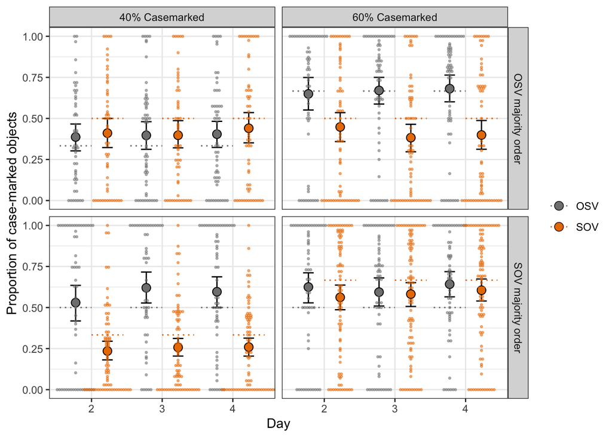

```r
data$casemarked_numeric <- ifelse(data$casemarked==FALSE,0,1)
case.summary.by.order.collapsed <- aggregate(casemarked_numeric~Day+WordOrder+ProportionMarked+MajorityInputOrder+workerId,data=subset(data,Block=="SentenceTest1" & grammatical),FUN=mean)


#Input levels
sov.40.inputs <- data.frame(Day=rep(c(1,2,3),2),
                          WordOrder=rep(c('OSV','SOV'),each=3),
                          casemarked_numeric=rep(c(1/2,1/3),each=3),
                          MajorityInputOrder="SOV majority order",
                          ProportionMarked="40% Casemarked")
sov.60.inputs <- data.frame(Day=rep(c(1,2,3),2),
                          WordOrder=rep(c('OSV','SOV'),each=3),
                          casemarked_numeric=rep(c(1/2,2/3),each=3),
                          MajorityInputOrder="SOV majority order",
                          ProportionMarked="60% Casemarked")
osv.40.inputs <- data.frame(Day=rep(c(1,2,3),2),
                          WordOrder=rep(c('OSV','SOV'),each=3),
                          casemarked_numeric=rep(c(1/3,1/2),each=3),
                          MajorityInputOrder="OSV majority order",
                          ProportionMarked="40% Casemarked")
osv.60.inputs <- data.frame(Day=rep(c(1,2,3),2),
                          WordOrder=rep(c('OSV','SOV'),each=3),
                          casemarked_numeric=rep(c(2/3,1/2),each=3),
                          MajorityInputOrder="OSV majority order",
                          ProportionMarked="60% Casemarked")

word.order.case.inputs <- rbind(sov.40.inputs,sov.60.inputs,osv.40.inputs,osv.60.inputs)



ggplot(data=case.summary.by.order.collapsed, aes(x=Day, y=casemarked_numeric, fill=WordOrder, colour=WordOrder)) +
  facet_grid(MajorityInputOrder~ProportionMarked) +
  #points and CIs for marking by word order
  stat_summary(geom='errorbar', fun.data='mean_cl_boot',fun.min="min", fun.max="max",width=0.3,position=position_dodge(0.9),color='black') +
  stat_summary(geom='point', fun='mean', position=position_dodge(0.9), size=3) +
  stat_summary(geom='point', fun='mean', position=position_dodge(0.9), size=3, shape=1, colour='black') +

  #horizontal lines showing input
  geom_errorbar(data=word.order.case.inputs, aes(x=Day,ymax=casemarked_numeric, ymin=casemarked_numeric),position=position_dodge(0.9),linetype=3) +

  #by-participant data
  geom_dotplot(binaxis = "y", stackdir = "center",alpha=0.5,dotsize=1.4,position=position_dodge(0.9),binpositions='all',binwidth=1/100) +

  #then various axis/legend stuff
  xlab("Day") +
  theme_bw() +
  ylab("Proportion of case-marked objects") +
  theme(legend.title=element_blank()) +
  scale_fill_manual(values=my.colours) +
  scale_colour_manual(values=my.colours)
```

```r
ggsave("Figures/case-by-order-collapsed.pdf",width=9, height=4.5)
```

For the stat, going to use OrderMarkedMore as the predictor instead of MajorityInputOrder, otherwise the interactions get even more complex!

Contrast coding for analysis - dummy code for Day and OrderMarkedMore (re-levelling so SOV marked more is the reference level), deviation code everything else.

```r
contrasts(data$Day) <- NULL
data$OrderMarkedMoreSOVRef <- relevel(data$OrderMarkedMore,ref="SOV marked more")
contrasts(data$OrderMarkedMoreSOVRef) <- NULL
contrasts(data$WordOrder) <- c(-0.5,0.5)
contrasts(data$ProportionMarked) <- c(-0.5,0.5)
```

```r
case.order.model.1 <- glmer(casemarked ~ WordOrder * Day * ProportionMarked * OrderMarkedMoreSOVRef + (1  + WordOrder * Day | workerId),data=subset(data,Block=="SentenceTest1" & grammatical),family=binomial,control=glmerControl(optimizer="bobyqa",optCtrl=list(maxfun=50000)))
```

```r
summary(case.order.model.1)
```

```
## Generalized linear mixed model fit by maximum likelihood (Laplace Approximation) ['glmerMod']
##  Family: binomial  ( logit )
## Formula: casemarked ~ WordOrder * Day * ProportionMarked * OrderMarkedMoreSOVRef +      (1 + WordOrder * Day | workerId)
##    Data: subset(data, Block == "SentenceTest1" & grammatical)
## Control: glmerControl(optimizer = "bobyqa", optCtrl = list(maxfun = 50000))
##
##      AIC      BIC   logLik deviance df.resid
##  27980.3  28357.0 -13945.1  27890.3    31922
##
## Scaled residuals:
##     Min      1Q  Median      3Q     Max
## -6.7086 -0.4771 -0.0643  0.4995  7.1259
##
## Random effects:
##  Groups   Name            Variance Std.Dev. Corr
##  workerId (Intercept)     6.850    2.617
##           WordOrder1      3.680    1.918     0.08
##           Day3            1.937    1.392    -0.37  0.06
##           Day4            3.035    1.742    -0.37 -0.05  0.82
##           WordOrder1:Day3 4.487    2.118    -0.03 -0.67  0.11  0.19
##           WordOrder1:Day4 4.784    2.187    -0.09 -0.63  0.20  0.31  0.92
## Number of obs: 31967, groups:  workerId, 309
##
## Fixed effects:
##                                                                        Estimate Std. Error z value Pr(>|z|)
## (Intercept)                                                            -0.38674    0.22796  -1.697 0.089788 .
## WordOrder1                                                             -0.08313    0.22165  -0.375 0.707627
## Day3                                                                    0.16320    0.15058   1.084 0.278437
## Day4                                                                    0.33618    0.17381   1.934 0.053088 .
## ProportionMarked1                                                       1.65207    0.44943   3.676 0.000237 ***
## OrderMarkedMoreSOVRefOSV marked more                                   -0.04189    0.32369  -0.129 0.897025
## WordOrder1:Day3                                                         0.10798    0.25405   0.425 0.670810
## WordOrder1:Day4                                                         0.11536    0.25959   0.444 0.656762
## WordOrder1:ProportionMarked1                                           -0.40973    0.42932  -0.954 0.339896
## Day3:ProportionMarked1                                                 -0.09961    0.29508  -0.338 0.735671
## Day4:ProportionMarked1                                                 -0.05816    0.34421  -0.169 0.865825
## WordOrder1:OrderMarkedMoreSOVRefOSV marked more                        -1.79133    0.31575  -5.673  1.4e-08 ***
## Day3:OrderMarkedMoreSOVRefOSV marked more                              -0.07700    0.21420  -0.359 0.719235
## Day4:OrderMarkedMoreSOVRefOSV marked more                              -0.28336    0.24809  -1.142 0.253392
## ProportionMarked1:OrderMarkedMoreSOVRefOSV marked more                 -0.17072    0.63635  -0.268 0.788482
## WordOrder1:Day3:ProportionMarked1                                       0.26791    0.48869   0.548 0.583539
## WordOrder1:Day4:ProportionMarked1                                       0.20385    0.49488   0.412 0.680400
## WordOrder1:Day3:OrderMarkedMoreSOVRefOSV marked more                   -0.24828    0.36331  -0.683 0.494362
## WordOrder1:Day4:OrderMarkedMoreSOVRefOSV marked more                   -0.42569    0.37302  -1.141 0.253781
## WordOrder1:ProportionMarked1:OrderMarkedMoreSOVRefOSV marked more       0.99062    0.60728   1.631 0.102839
## Day3:ProportionMarked1:OrderMarkedMoreSOVRefOSV marked more            -0.37989    0.42096  -0.902 0.366833
## Day4:ProportionMarked1:OrderMarkedMoreSOVRefOSV marked more            -0.14481    0.49220  -0.294 0.768593
## WordOrder1:Day3:ProportionMarked1:OrderMarkedMoreSOVRefOSV marked more -0.22765    0.68949  -0.330 0.741273
## WordOrder1:Day4:ProportionMarked1:OrderMarkedMoreSOVRefOSV marked more -0.46605    0.70077  -0.665 0.506011
## ---
## Signif. codes:  0 '***' 0.001 '**' 0.01 '*' 0.05 '.' 0.1 ' ' 1
```

```
##
## Correlation matrix not shown by default, as p = 24 > 12.
## Use print(x, correlation=TRUE)  or
##     vcov(x)        if you need it
```

# Case marking and animacy

Check for the overall pattern of results - any hint of a DOM effect?

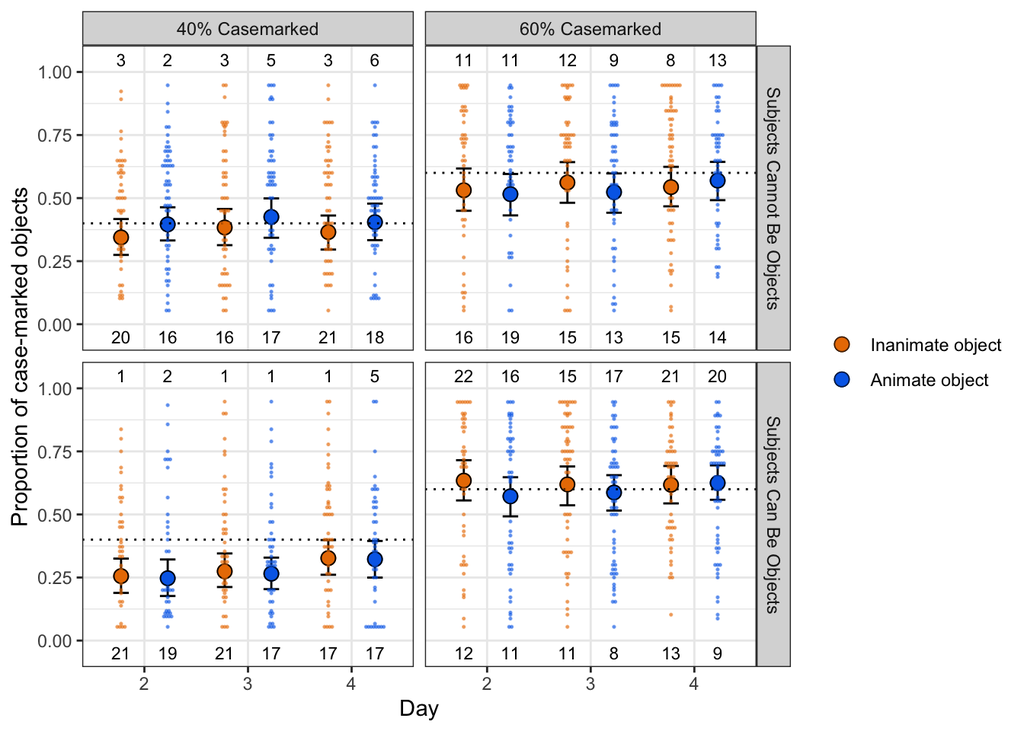

```r
casemarking.summary.by.animacy <- aggregate(casemarked_numeric~Animacy+Day+ProportionMarked+EventType+workerId,data=subset(data,Block=="SentenceTest1" & grammatical),FUN=mean)

#There are a lot of participants at extreme values in *both* directions here, so need to add text annotations at both ends of the plot.
casemarking.summary.by.animacy$IsCeiling <- ifelse(casemarking.summary.by.animacy$casemarked_numeric==1,1,0)
casemarking.summary.by.animacy$IsFloor <- ifelse(casemarking.summary.by.animacy$casemarked_numeric==0,1,0)

casemarking.summary.by.animacy$Day <- droplevels(casemarking.summary.by.animacy$Day)

casemarking.ceiling.ns.collapsed <- data.frame(summarize(group_by(subset(casemarking.summary.by.animacy,IsCeiling==1 & Day!=1),Day,Animacy,ProportionMarked,EventType,.drop = FALSE),n()))
casemarking.floor.ns.collapsed <- data.frame(summarize(group_by(subset(casemarking.summary.by.animacy,IsFloor==1 & Day!=1),Day,Animacy,ProportionMarked,EventType,.drop = FALSE),n()))
casemarking.ceiling.ns.collapsed <- plyr::rename(casemarking.ceiling.ns.collapsed,c("n.."="count"))
casemarking.floor.ns.collapsed <- plyr::rename(casemarking.floor.ns.collapsed,c("n.."="count"))

#need to specify input split by ProportionMarked
inputs <- data.frame(Day=rep(c(1,2,3),2),
                               ProportionMarked=rep(c("40% Casemarked","60% Casemarked"),each=3),
                               casemarked=rep(c(2/5,3/5),each=3))



ggplot(data=casemarking.summary.by.animacy, aes(x=Day, y=casemarked_numeric,
                                                     colour=Animacy,fill=Animacy)) +
  facet_grid(EventType~ProportionMarked) +
  #bars and CIs for casemarking by animacy
  stat_summary(geom='errorbar', fun.data='mean_cl_boot',fun.min="min", fun.max="max",width=0.3,position=position_dodge(0.9),colour='black') +
  stat_summary(geom='point',fun='mean', position=position_dodge(0.9),size=3) +
  stat_summary(geom='point',fun='mean', position=position_dodge(0.9),size=3,shape=1,colour='black') +

  #horizontal lines showing input
 geom_hline(dat=inputs,aes(yintercept=casemarked),linetype=3) +

  #by-participant data
  geom_dotplot(data=subset(casemarking.summary.by.animacy,IsCeiling!=1 & IsFloor!=1),binaxis = "y", stackdir = "center",alpha=0.5,dotsize=1,position=position_dodge(0.9),binpositions='all',binwidth=1/100) +
  geom_text(data=casemarking.ceiling.ns.collapsed,aes(x=Day,y=1.05,label=count),position=position_dodge(0.9),size=3,colour='black') +
  geom_text(data=casemarking.floor.ns.collapsed,aes(x=Day,y=-0.05,label=count),position=position_dodge(0.9),size=3,colour='black') +

  #then various axis/legend stuff
  xlab("Day") +
  theme_bw() +
  ylab("Proportion of case-marked objects") +
  theme(legend.title=element_blank()) +
  scale_fill_manual(values=my.colours[2:3],breaks=c("FALSE", "TRUE"),labels=c("Inanimate object", "Animate object")) +
  scale_colour_manual(values=my.colours[2:3],breaks=c("FALSE", "TRUE"),labels=c("Inanimate object", "Animate object"))
```

```r
ggsave("Figures/casemarking.pdf",width=9, height=6)
```

Stat. Dummy-code Day so that intercept is day=2, deviation-code everything else.

```r
contrasts(data$Day) <- NULL
contrasts(data$Animacy) <- c(-0.5,0.5)
contrasts(data$EventType) <- c(-0.5,0.5)
contrasts(data$ProportionMarked) <- c(-0.5,0.5)
contrasts(data$MajorityInputOrder) <- c(-0.5,0.5)
contrasts(data$OrderMarkedMore) <- c(-0.5,0.5)

#will want a model where day 4 is the reference level (to confirm no DOM effect)
data$Day4Ref <- relevel(data$Day,ref="4")
contrasts(data$Day4Ref) <- NULL
```

Simpler model - dropping anything on word order in the input since this produces a slightly easier to interpret set of stats, although in the paper we include the second more complex model.

```r
case.marking.model.1 <- glmer(casemarked ~ Animacy * ProportionMarked * EventType* Day + (1 + Animacy * Day | workerId),data=subset(data,Block=="SentenceTest1" & grammatical),family=binomial,control=glmerControl(optimizer="bobyqa",optCtrl=list(maxfun=50000)))
```

```r
summary(case.marking.model.1)
```

```
## Generalized linear mixed model fit by maximum likelihood (Laplace Approximation) ['glmerMod']
##  Family: binomial  ( logit )
## Formula: casemarked ~ Animacy * ProportionMarked * EventType * Day + (1 +      Animacy * Day | workerId)
##    Data: subset(data, Block == "SentenceTest1" & grammatical)
## Control: glmerControl(optimizer = "bobyqa", optCtrl = list(maxfun = 50000))
##
##      AIC      BIC   logLik deviance df.resid
##  28248.3  28625.0 -14079.1  28158.3    31922
##
## Scaled residuals:
##     Min      1Q  Median      3Q     Max
## -6.8949 -0.4790 -0.0692  0.5310  6.2589
##
## Random effects:
##  Groups   Name          Variance Std.Dev. Corr
##  workerId (Intercept)   7.640    2.764
##           Animacy1      2.319    1.523    -0.13
##           Day3          2.650    1.628    -0.34  0.11
##           Day4          3.961    1.990    -0.34 -0.01  0.81
##           Animacy1:Day3 1.998    1.414     0.05 -0.38 -0.20 -0.09
##           Animacy1:Day4 1.856    1.363     0.18 -0.39 -0.09  0.00  0.87
## Number of obs: 31967, groups:  workerId, 309
##
## Fixed effects:
##                                             Estimate Std. Error z value Pr(>|z|)
## (Intercept)                                -0.718609   0.167098  -4.301 1.70e-05 ***
## Animacy1                                    0.007842   0.120290   0.065   0.9480
## ProportionMarked1                           1.949611   0.331930   5.874 4.27e-09 ***
## EventType1                                 -0.081233   0.330785  -0.246   0.8060
## Day3                                        0.211749   0.113094   1.872   0.0612 .
## Day4                                        0.311356   0.131930   2.360   0.0183 *
## Animacy1:ProportionMarked1                 -0.554039   0.235216  -2.355   0.0185 *
## Animacy1:EventType1                        -0.272204   0.229688  -1.185   0.2360
## ProportionMarked1:EventType1                1.532169   0.650988   2.354   0.0186 *
## Animacy1:Day3                              -0.017276   0.131873  -0.131   0.8958
## Animacy1:Day4                               0.093113   0.129426   0.719   0.4719
## ProportionMarked1:Day3                     -0.150027   0.224089  -0.669   0.5032
## ProportionMarked1:Day4                     -0.065619   0.262389  -0.250   0.8025
## EventType1:Day3                            -0.051577   0.221356  -0.233   0.8158
## EventType1:Day4                             0.253775   0.259971   0.976   0.3290
## Animacy1:ProportionMarked1:EventType1      -0.102822   0.449853  -0.229   0.8192
## Animacy1:ProportionMarked1:Day3             0.150800   0.257992   0.585   0.5589
## Animacy1:ProportionMarked1:Day4             0.599897   0.253823   2.363   0.0181 *
## Animacy1:EventType1:Day3                    0.128001   0.249144   0.514   0.6074
## Animacy1:EventType1:Day4                    0.061560   0.243635   0.253   0.8005
## ProportionMarked1:EventType1:Day3           0.073267   0.434544   0.169   0.8661
## ProportionMarked1:EventType1:Day4          -0.419592   0.507031  -0.828   0.4079
## Animacy1:ProportionMarked1:EventType1:Day3  0.521757   0.490528   1.064   0.2875
## Animacy1:ProportionMarked1:EventType1:Day4  0.243686   0.479754   0.508   0.6115
## ---
## Signif. codes:  0 '***' 0.001 '**' 0.01 '*' 0.05 '.' 0.1 ' ' 1
```

```
##
## Correlation matrix not shown by default, as p = 24 > 12.
## Use print(x, correlation=TRUE)  or
##     vcov(x)        if you need it
```

Including OrderMarkedMore, to account for learning of conditioning of casemarking on order in those conditions. Still nothing involving Animacy.

```r
case.marking.model.2 <- glmer(casemarked ~ Animacy * ProportionMarked * OrderMarkedMore * EventType* Day + (1 + Animacy * Day | workerId),data=subset(data,Block=="SentenceTest1" & grammatical),family=binomial,control=glmerControl(optimizer="bobyqa",optCtrl=list(maxfun=50000)))
```

```r
summary(case.marking.model.2)
```

```
## Generalized linear mixed model fit by maximum likelihood (Laplace Approximation) ['glmerMod']
##  Family: binomial  ( logit )
## Formula: casemarked ~ Animacy * ProportionMarked * OrderMarkedMore * EventType *      Day + (1 + Animacy * Day | workerId)
##    Data: subset(data, Block == "SentenceTest1" & grammatical)
## Control: glmerControl(optimizer = "bobyqa", optCtrl = list(maxfun = 50000))
##
##      AIC      BIC   logLik deviance df.resid
##  28273.6  28851.3 -14067.8  28135.6    31898
##
## Scaled residuals:
##     Min      1Q  Median      3Q     Max
## -6.5893 -0.4785 -0.0681  0.5285  6.3917
##
## Random effects:
##  Groups   Name          Variance Std.Dev. Corr
##  workerId (Intercept)   7.491    2.737
##           Animacy1      2.285    1.511    -0.10
##           Day3          2.628    1.621    -0.34  0.10
##           Day4          3.913    1.978    -0.34 -0.01  0.81
##           Animacy1:Day3 1.974    1.405     0.03 -0.37 -0.19 -0.08
##           Animacy1:Day4 1.763    1.328     0.16 -0.38 -0.09  0.00  0.88
## Number of obs: 31967, groups:  workerId, 309
##
## Fixed effects:
##                                                              Estimate Std. Error z value Pr(>|z|)
## (Intercept)                                                 -0.727188   0.166903  -4.357 1.32e-05 ***
## Animacy1                                                    -0.007672   0.121092  -0.063   0.9495
## ProportionMarked1                                            1.965789   0.331697   5.926 3.10e-09 ***
## OrderMarkedMore1                                             0.235435   0.330605   0.712   0.4764
## EventType1                                                  -0.044401   0.330241  -0.134   0.8930
## Day3                                                         0.204457   0.114049   1.793   0.0730 .
## Day4                                                         0.291482   0.132810   2.195   0.0282 *
## Animacy1:ProportionMarked1                                  -0.513943   0.237325  -2.166   0.0303 *
## Animacy1:OrderMarkedMore1                                   -0.140651   0.231159  -0.608   0.5429
## ProportionMarked1:OrderMarkedMore1                          -0.115383   0.648303  -0.178   0.8587
## Animacy1:EventType1                                         -0.325896   0.231269  -1.409   0.1588
## ProportionMarked1:EventType1                                 1.627998   0.648724   2.510   0.0121 *
## OrderMarkedMore1:EventType1                                 -1.419138   0.648313  -2.189   0.0286 *
## Animacy1:Day3                                               -0.013606   0.132927  -0.102   0.9185
## Animacy1:Day4                                                0.091877   0.129470   0.710   0.4779
```

[output cut: 20 more lines]

```
## OrderMarkedMore1:EventType1:Day3                             0.509041   0.439468   1.158   0.2467
## OrderMarkedMore1:EventType1:Day4                             0.123132   0.514894   0.239   0.8110
## Animacy1:ProportionMarked1:OrderMarkedMore1:EventType1       1.131006   0.887306   1.275   0.2024
## Animacy1:ProportionMarked1:OrderMarkedMore1:Day3             0.182581   0.489267   0.373   0.7090
## Animacy1:ProportionMarked1:OrderMarkedMore1:Day4             0.579888   0.475292   1.220   0.2224
## Animacy1:ProportionMarked1:EventType1:Day3                   0.587319   0.493280   1.191   0.2338
## Animacy1:ProportionMarked1:EventType1:Day4                   0.246199   0.478439   0.515   0.6068
## Animacy1:OrderMarkedMore1:EventType1:Day3                   -0.334561   0.495235  -0.676   0.4993
## Animacy1:OrderMarkedMore1:EventType1:Day4                    0.160361   0.482626   0.332   0.7397
## ProportionMarked1:OrderMarkedMore1:EventType1:Day3           0.522911   0.809718   0.646   0.5184
## ProportionMarked1:OrderMarkedMore1:EventType1:Day4           1.535358   0.942076   1.630   0.1032
## Animacy1:ProportionMarked1:OrderMarkedMore1:EventType1:Day3 -1.158248   0.932884  -1.242   0.2144
## Animacy1:ProportionMarked1:OrderMarkedMore1:EventType1:Day4 -0.865948   0.899666  -0.963   0.3358
## ---
## Signif. codes:  0 '***' 0.001 '**' 0.01 '*' 0.05 '.' 0.1 ' ' 1
```

```
##
## Correlation matrix not shown by default, as p = 48 > 12.
## Use print(x, correlation=TRUE)  or
##     vcov(x)        if you need it
```

Same, but re-levelled to check for Animacy effect at Day 4 - still no effect of animacy at Day 4, there is a marginal 3-way interaction Animacy1:ProportionMarked1:OrderMarkedMore1 which seems to be due to the OSV-majority, 60% casemarked language looking slightly different.

```r
case.marking.model.3 <- glmer(casemarked ~ Animacy * ProportionMarked * OrderMarkedMore * EventType* Day4Ref + (1 + Animacy * Day4Ref | workerId),data=subset(data,Block=="SentenceTest1" & grammatical),family=binomial,control=glmerControl(optimizer="bobyqa",optCtrl=list(maxfun=50000)))
```

```r
summary(case.marking.model.3)
```

```
## Generalized linear mixed model fit by maximum likelihood (Laplace Approximation) ['glmerMod']
##  Family: binomial  ( logit )
## Formula: casemarked ~ Animacy * ProportionMarked * OrderMarkedMore * EventType *      Day4Ref + (1 + Animacy * Day4Ref | workerId)
##    Data: subset(data, Block == "SentenceTest1" & grammatical)
## Control: glmerControl(optimizer = "bobyqa", optCtrl = list(maxfun = 50000))
##
##      AIC      BIC   logLik deviance df.resid
##  28273.6  28851.3 -14067.8  28135.6    31898
##
## Scaled residuals:
##     Min      1Q  Median      3Q     Max
## -6.5891 -0.4785 -0.0681  0.5285  6.3917
##
## Random effects:
##  Groups   Name              Variance Std.Dev. Corr
##  workerId (Intercept)       7.7289   2.7801
##           Animacy1          2.5076   1.5835    0.02
##           Day4Ref2          3.9128   1.9781   -0.38  0.01
##           Day4Ref3          1.3453   1.1599   -0.31  0.04  0.57
##           Animacy1:Day4Ref2 1.7630   1.3278   -0.16 -0.47  0.00  0.14
##           Animacy1:Day4Ref3 0.4575   0.6764   -0.36 -0.13  0.18 -0.01  0.14
## Number of obs: 31967, groups:  workerId, 309
##
## Fixed effects:
##                                                                 Estimate Std. Error z value Pr(>|z|)
## (Intercept)                                                     -0.43570    0.16512  -2.639  0.00832 **
## Animacy1                                                         0.08420    0.11414   0.738  0.46067
## ProportionMarked1                                                1.88827    0.32821   5.753 8.75e-09 ***
## OrderMarkedMore1                                                 0.52829    0.32743   1.613  0.10665
## EventType1                                                       0.17872    0.32746   0.546  0.58522
## Day4Ref2                                                        -0.29151    0.13282  -2.195  0.02818 *
## Day4Ref3                                                        -0.08704    0.08495  -1.025  0.30557
## Animacy1:ProportionMarked1                                       0.02034    0.22913   0.089  0.92927
## Animacy1:OrderMarkedMore1                                        0.08302    0.22417   0.370  0.71113
## ProportionMarked1:OrderMarkedMore1                               0.11581    0.65285   0.177  0.85920
## Animacy1:EventType1                                             -0.24567    0.22340  -1.100  0.27147
## ProportionMarked1:EventType1                                     1.14342    0.65317   1.751  0.08002 .
## OrderMarkedMore1:EventType1                                     -1.29577    0.65349  -1.983  0.04739 *
## Animacy1:Day4Ref2                                               -0.09187    0.12960  -0.709  0.47839
## Animacy1:Day4Ref3                                               -0.10548    0.09524  -1.108  0.26806
```

[output cut: 20 more lines]

```
## OrderMarkedMore1:EventType1:Day4Ref2                            -0.12333    0.51641  -0.239  0.81124
## OrderMarkedMore1:EventType1:Day4Ref3                             0.38582    0.33151   1.164  0.24449
## Animacy1:ProportionMarked1:OrderMarkedMore1:EventType1           0.26472    0.85443   0.310  0.75669
## Animacy1:ProportionMarked1:OrderMarkedMore1:Day4Ref2            -0.58001    0.48307  -1.201  0.22987
## Animacy1:ProportionMarked1:OrderMarkedMore1:Day4Ref3            -0.39736    0.35477  -1.120  0.26270
## Animacy1:ProportionMarked1:EventType1:Day4Ref2                  -0.24632    0.48624  -0.507  0.61245
## Animacy1:ProportionMarked1:EventType1:Day4Ref3                   0.34108    0.35858   0.951  0.34150
## Animacy1:OrderMarkedMore1:EventType1:Day4Ref2                   -0.16036    0.48980  -0.327  0.74336
## Animacy1:OrderMarkedMore1:EventType1:Day4Ref3                   -0.49495    0.35992  -1.375  0.16908
## ProportionMarked1:OrderMarkedMore1:EventType1:Day4Ref2          -1.53459    0.98009  -1.566  0.11740
## ProportionMarked1:OrderMarkedMore1:EventType1:Day4Ref3          -1.01226    0.64319  -1.574  0.11553
## Animacy1:ProportionMarked1:OrderMarkedMore1:EventType1:Day4Ref2  0.86675    0.92246   0.940  0.34742
## Animacy1:ProportionMarked1:OrderMarkedMore1:EventType1:Day4Ref3 -0.29218    0.69158  -0.422  0.67267
## ---
## Signif. codes:  0 '***' 0.001 '**' 0.01 '*' 0.05 '.' 0.1 ' ' 1
```

```
##
## Correlation matrix not shown by default, as p = 48 > 12.
## Use print(x, correlation=TRUE)  or
##     vcov(x)        if you need it
```

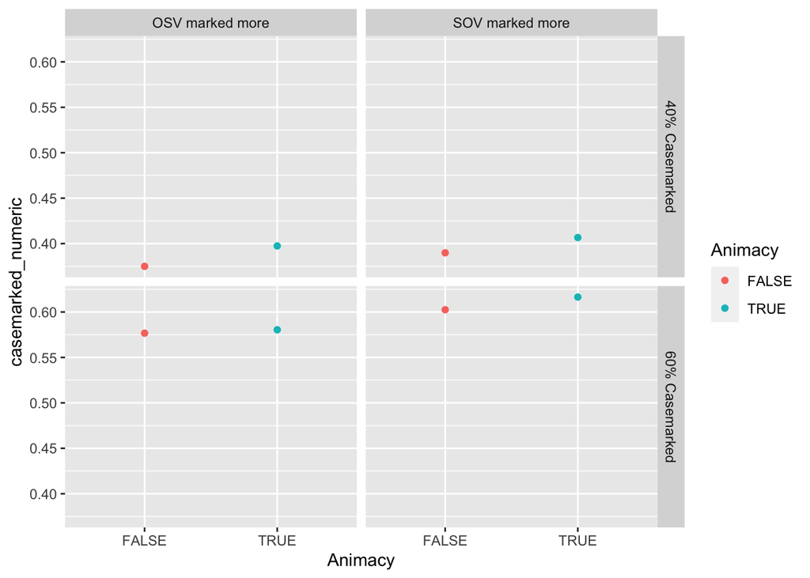

```r
aggregate(casemarked_numeric~Animacy+ProportionMarked+OrderMarkedMore,data=subset(data,Day==4),FUN=mean) -> temp
ggplot(data=temp, aes(x=Animacy, y=casemarked_numeric,
                                                     colour=Animacy,fill=Animacy)) +
  facet_grid(ProportionMarked~OrderMarkedMore) +
  geom_point()
```

A couple of additional models of interest that we want to check for DOM-like effects at day 4.

The SOV-majority, 60% casemarking language is the FNJ Experiment 1 language.

```r
fnjlanguage.marking.model.1 <- glmer(casemarked ~ Animacy * EventType* Day4Ref + (1 + Animacy * Day4Ref | workerId),data=subset(data,Block=="SentenceTest1" & grammatical & ProportionMarked=="60% Casemarked" & MajorityInputOrder=="SOV majority order"),family=binomial,control=glmerControl(optimizer="bobyqa",optCtrl=list(maxfun=50000)))
```

No significant animacy effect at Day 4.

```r
summary(fnjlanguage.marking.model.1)
```

```
## Generalized linear mixed model fit by maximum likelihood (Laplace Approximation) ['glmerMod']
##  Family: binomial  ( logit )
## Formula: casemarked ~ Animacy * EventType * Day4Ref + (1 + Animacy * Day4Ref |      workerId)
##    Data: subset(data, Block == "SentenceTest1" & grammatical & ProportionMarked ==      "60% Casemarked" & MajorityInputOrder == "SOV majority order")
## Control: glmerControl(optimizer = "bobyqa", optCtrl = list(maxfun = 50000))
##
##      AIC      BIC   logLik deviance df.resid
##   8094.8   8331.0  -4014.4   8028.8     9460
##
## Scaled residuals:
##     Min      1Q  Median      3Q     Max
## -5.5081 -0.2985  0.1409  0.5002  5.8437
##
## Random effects:
##  Groups   Name              Variance Std.Dev. Corr
##  workerId (Intercept)       8.896    2.9826
##           Animacy1          2.786    1.6691   -0.12
##           Day4Ref2          5.568    2.3596   -0.33  0.06
##           Day4Ref3          1.611    1.2691   -0.11  0.02  0.65
##           Animacy1:Day4Ref2 2.120    1.4561    0.05 -0.38 -0.03  0.04
##           Animacy1:Day4Ref3 0.771    0.8781   -0.30  0.07  0.04 -0.23 -0.08
## Number of obs: 9493, groups:  workerId, 91
##
## Fixed effects:
##                               Estimate Std. Error z value Pr(>|z|)
## (Intercept)                   0.809350   0.322437   2.510  0.01207 *
## Animacy1                      0.342472   0.216376   1.583  0.11348
## EventType1                    0.405687   0.643078   0.631  0.52814
## Day4Ref2                     -0.457552   0.276366  -1.656  0.09780 .
## Day4Ref3                     -0.203804   0.164453  -1.239  0.21524
## Animacy1:EventType1           0.030919   0.429453   0.072  0.94260
## Animacy1:Day4Ref2            -0.618796   0.238015  -2.600  0.00933 **
## Animacy1:Day4Ref3            -0.494667   0.184392  -2.683  0.00730 **
## EventType1:Day4Ref2          -0.424923   0.551604  -0.770  0.44110
## EventType1:Day4Ref3          -0.054970   0.329636  -0.167  0.86756
## Animacy1:EventType1:Day4Ref2 -0.006861   0.471762  -0.015  0.98840
## Animacy1:EventType1:Day4Ref3 -0.065785   0.367002  -0.179  0.85774
## ---
## Signif. codes:  0 '***' 0.001 '**' 0.01 '*' 0.05 '.' 0.1 ' ' 1
##
## Correlation of Fixed Effects:
##             (Intr) Anmcy1 EvntT1 Dy4Rf2 Dy4Rf3 An1:ET1 A1:D4R2 A1:D4R3 ET1:D4R2 ET1:D4R3 A1:ET1:D4R2
## Animacy1    -0.090
## EventType1  -0.053 -0.004
## Day4Ref2    -0.343  0.035  0.012
## Day4Ref3    -0.170  0.004  0.001  0.594
## Anmcy1:EvT1 -0.002 -0.035 -0.096  0.001  0.003
## Anmcy1:D4R2  0.028 -0.473  0.005 -0.021  0.032  0.001
## Anmcy1:D4R3 -0.153 -0.264  0.014  0.029 -0.120 -0.008   0.239
## EvntT1:D4R2  0.013  0.004 -0.343 -0.045 -0.027  0.042  -0.009  -0.006
## EvntT1:D4R3  0.001  0.008 -0.169 -0.024 -0.043  0.014  -0.011  -0.004   0.595
## A1:ET1:D4R2  0.003 -0.003  0.033 -0.005 -0.006 -0.469  -0.005   0.011  -0.029    0.023
## A1:ET1:D4R3  0.011 -0.012 -0.146 -0.003  0.002 -0.249   0.013  -0.029   0.018   -0.137    0.227
```

The OSV-majority, 40% casemarking language has no preference to overuse OSV with animates (because it’s OSV majority) *and* no tendency to condition casemarking on word order (because it marks SOV more often than OSV).

```r
otherlanguage.marking.model.1 <- glmer(casemarked ~ Animacy * EventType* Day4Ref + (1 + Animacy * Day4Ref | workerId),data=subset(data,Block=="SentenceTest1" & grammatical & ProportionMarked=="40% Casemarked" & MajorityInputOrder=="OSV majority order"),family=binomial,control=glmerControl(optimizer="bobyqa",optCtrl=list(maxfun=50000)))
```

No significant animacy effect at Day 4.

```r
summary(otherlanguage.marking.model.1)
```

```
## Generalized linear mixed model fit by maximum likelihood (Laplace Approximation) ['glmerMod']
##  Family: binomial  ( logit )
## Formula: casemarked ~ Animacy * EventType * Day4Ref + (1 + Animacy * Day4Ref |      workerId)
##    Data: subset(data, Block == "SentenceTest1" & grammatical & ProportionMarked ==      "40% Casemarked" & MajorityInputOrder == "OSV majority order")
## Control: glmerControl(optimizer = "bobyqa", optCtrl = list(maxfun = 50000))
##
##      AIC      BIC   logLik deviance df.resid
##   6482.9   6708.4  -3208.4   6416.9     6826
##
## Scaled residuals:
##     Min      1Q  Median      3Q     Max
## -6.1867 -0.5464 -0.1334  0.6058  5.9739
##
## Random effects:
##  Groups   Name              Variance Std.Dev. Corr
##  workerId (Intercept)       6.1566   2.4812
##           Animacy1          2.4387   1.5616    0.25
##           Day4Ref2          2.3829   1.5437   -0.64 -0.15
##           Day4Ref3          0.5682   0.7538   -0.32 -0.08  0.57
##           Animacy1:Day4Ref2 1.6606   1.2886   -0.56 -0.43  0.33  0.38
##           Animacy1:Day4Ref3 0.3473   0.5893   -0.60  0.06  0.31  0.08  0.30
## Number of obs: 6859, groups:  workerId, 67
##
## Fixed effects:
##                              Estimate Std. Error z value Pr(>|z|)
## (Intercept)                  -1.10155    0.32148  -3.427 0.000611 ***
## Animacy1                     -0.19769    0.24918  -0.793 0.427551
## EventType1                   -1.27968    0.63926  -2.002 0.045303 *
## Day4Ref2                     -0.21984    0.23757  -0.925 0.354765
## Day4Ref3                     -0.13012    0.14614  -0.890 0.373238
## Animacy1:EventType1          -0.30052    0.48172  -0.624 0.532727
## Animacy1:Day4Ref2             0.33800    0.28637   1.180 0.237886
## Animacy1:Day4Ref3             0.14281    0.21656   0.659 0.509619
## EventType1:Day4Ref2           0.01778    0.45868   0.039 0.969075
## EventType1:Day4Ref3          -0.10010    0.27610  -0.363 0.716953
## Animacy1:EventType1:Day4Ref2 -0.18006    0.52015  -0.346 0.729218
## Animacy1:EventType1:Day4Ref3 -0.27591    0.39046  -0.707 0.479808
## ---
## Signif. codes:  0 '***' 0.001 '**' 0.01 '*' 0.05 '.' 0.1 ' ' 1
##
## Correlation of Fixed Effects:
##             (Intr) Anmcy1 EvntT1 Dy4Rf2 Dy4Rf3 An1:ET1 A1:D4R2 A1:D4R3 ET1:D4R2 ET1:D4R3 A1:ET1:D4R2
## Animacy1     0.214
## EventType1   0.189  0.047
## Day4Ref2    -0.596 -0.142 -0.123
## Day4Ref3    -0.323 -0.098 -0.078  0.485
## Anmcy1:EvT1  0.049  0.260  0.213 -0.042 -0.035
## Anmcy1:D4R2 -0.329 -0.497 -0.067  0.151  0.203 -0.153
## Anmcy1:D4R3 -0.224 -0.328 -0.047  0.128  0.092 -0.118   0.368
## EvntT1:D4R2 -0.125 -0.039 -0.604  0.247  0.118 -0.138   0.027   0.034
## EvntT1:D4R3 -0.080 -0.035 -0.321  0.116  0.280 -0.083   0.054   0.047   0.500
## A1:ET1:D4R2 -0.075 -0.155 -0.356  0.033  0.059 -0.499   0.338   0.126   0.175    0.212
## A1:ET1:D4R3 -0.054 -0.125 -0.236  0.041  0.051 -0.295   0.129   0.353   0.126    0.068    0.372
```

# Case marking and animacy during interaction

```r
#since there is some data munging here, will set this up as a seperate data frame
recall.vs.interaction.data <- subset(data,(Block=="Interaction" | Block=="SentenceTest1") & grammatical & Day==4)
#want recall to be the reference level
recall.vs.interaction.data$Block <- relevel(droplevels(as.factor(recall.vs.interaction.data$Block)),ref="SentenceTest1")

recall.vs.interaction.summary <- aggregate(casemarked_numeric~Animacy+Block+EventType+ProportionMarked+workerId,data=recall.vs.interaction.data,FUN=mean)

#prettier names for printing
recall.vs.interaction.summary$Block <- revalue(recall.vs.interaction.summary$Block,
                                         c("SentenceTest1"="Recall",
                                           "Interaction"="Interaction"))
```

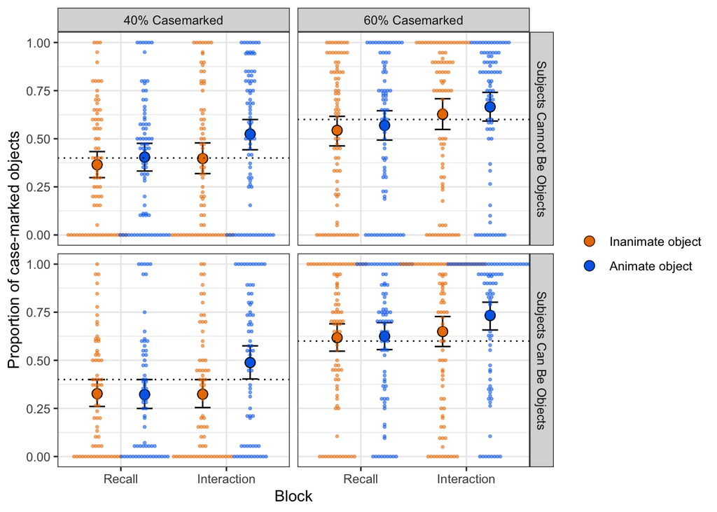

```r
ggplot(data=recall.vs.interaction.summary, aes(x=Block, y=casemarked_numeric,
                                                    colour=Animacy, fill=Animacy)) +
  facet_grid(EventType~ProportionMarked) +
  #points and CIs for casemarking by animacy
  stat_summary(geom='errorbar', fun.data='mean_cl_boot',fun.min="min", fun.max="max",width=0.3,position=position_dodge(0.9),color='black') +
  stat_summary(geom='point', fun='mean', position=position_dodge(0.9),size=3) +
  stat_summary(geom='point', fun='mean', position=position_dodge(0.9),size=3,
               shape=1,colour='black') +

  #horizontal lines showing input
  geom_hline(dat=inputs,aes(yintercept=casemarked),linetype=3) +
  #by-participant data
  geom_dotplot(binaxis = "y", stackdir = "center",alpha=0.5,dotsize=1.5,position=position_dodge(0.9),binpositions='all',binwidth=1/100) +
  #then various axis/legend stuff
  xlab("Block") +
  theme_bw() +
  ylab("Proportion of case-marked objects") +
  theme(legend.title=element_blank()) +
  scale_colour_manual(values=my.colours[2:3],breaks=c("FALSE", "TRUE"),labels=c("Inanimate object", "Animate object")) +
  scale_fill_manual(values=my.colours[2:3],breaks=c("FALSE", "TRUE"),labels=c("Inanimate object", "Animate object"))
```

```r
ggsave("Figures/interaction-casemarking.pdf",width=9, height=6)
```

Stat where block is treatment-coded (recall is intercept), everything else deviation coded.

```r
contrasts(recall.vs.interaction.data$Block) <- NULL
contrasts(recall.vs.interaction.data$ProportionMarked) <- c(-0.5,0.5)
contrasts(recall.vs.interaction.data$Animacy) <- c(-0.5,0.5)
contrasts(recall.vs.interaction.data$EventType) <- c(-0.5,0.5)
```

```r
recall.vs.interaction.model.1 <- glmer(casemarked ~ Animacy * Block * EventType * ProportionMarked + (1 + Animacy *  Block | workerId),data=recall.vs.interaction.data,family=binomial,control=glmerControl(optimizer="bobyqa"))
```

A highly significant effect of Block=interaction *and* an interaction of animacy and Block -i.e. you get DOM when in interaction. Plus a significant interaction with EventType, i.e. this effect is amplified when genuine ambiguity ensues. Negative interaction with ProportionMarked though, suggesting this effect is smaller in the 60% casemarked input languages, exploring that below.

```r
summary(recall.vs.interaction.model.1)
```

```
## Generalized linear mixed model fit by maximum likelihood (Laplace Approximation) ['glmerMod']
##  Family: binomial  ( logit )
## Formula: casemarked ~ Animacy * Block * EventType * ProportionMarked +      (1 + Animacy * Block | workerId)
##    Data: recall.vs.interaction.data
## Control: glmerControl(optimizer = "bobyqa")
##
##      AIC      BIC   logLik deviance df.resid
##  19402.8  19611.9  -9675.4  19350.8    22999
##
## Scaled residuals:
##     Min      1Q  Median      3Q     Max
## -6.3048 -0.3941  0.0706  0.4742  5.2241
##
## Random effects:
##  Groups   Name                      Variance Std.Dev. Corr
##  workerId (Intercept)               7.7121   2.7771
##           Animacy1                  2.5550   1.5984    0.01
##           BlockInteraction          2.6330   1.6227   -0.07 -0.15
##           Animacy1:BlockInteraction 0.9926   0.9963   -0.27  0.38  0.13
## Number of obs: 23025, groups:  workerId, 314
##
## Fixed effects:
##                                                        Estimate Std. Error z value Pr(>|z|)
## (Intercept)                                            -0.42035    0.16327  -2.575  0.01004 *
## Animacy1                                                0.15601    0.11328   1.377  0.16845
## BlockInteraction                                        0.65225    0.10829   6.023 1.71e-09 ***
## EventType1                                              0.19271    0.32539   0.592  0.55369
## ProportionMarked1                                       1.85698    0.32600   5.696 1.22e-08 ***
## Animacy1:BlockInteraction                               0.67014    0.10698   6.264 3.74e-10 ***
## Animacy1:EventType1                                    -0.20362    0.22160  -0.919  0.35817
## BlockInteraction:EventType1                             0.12669    0.21494   0.589  0.55557
## Animacy1:ProportionMarked1                             -0.17324    0.22630  -0.766  0.44396
## BlockInteraction:ProportionMarked1                      0.31582    0.21758   1.452  0.14663
## EventType1:ProportionMarked1                            1.04383    0.64334   1.623  0.10469
## Animacy1:BlockInteraction:EventType1                    0.56508    0.20867   2.708  0.00677 **
## Animacy1:BlockInteraction:ProportionMarked1            -0.54855    0.22231  -2.467  0.01361 *
## Animacy1:EventType1:ProportionMarked1                   0.07014    0.44144   0.159  0.87375
## BlockInteraction:EventType1:ProportionMarked1           0.18983    0.42816   0.443  0.65751
## Animacy1:BlockInteraction:EventType1:ProportionMarked1 -0.06729    0.41449  -0.162  0.87103
## ---
## Signif. codes:  0 '***' 0.001 '**' 0.01 '*' 0.05 '.' 0.1 ' ' 1
```

```
##
## Correlation matrix not shown by default, as p = 16 > 12.
## Use print(x, correlation=TRUE)  or
##     vcov(x)        if you need it
```

Do we see the effect of animacy in interaction in the 60% casemarked languages? Checking with a relevelled model.

```r
recall.vs.interaction.data$ProportionMarkedRef60 <- relevel(recall.vs.interaction.data$ProportionMarked,ref="60% Casemarked")
contrasts(recall.vs.interaction.data$ProportionMarkedRef60) <- NULL

recall.vs.interaction.model.ref60 <- glmer(casemarked ~ Animacy * Block * EventType * ProportionMarkedRef60 + (1 + Animacy *  Block | workerId),data=recall.vs.interaction.data,family=binomial,control=glmerControl(optimizer="bobyqa"))
```

This still shows a significant animacy x block interaction.

```r
summary(recall.vs.interaction.model.ref60)
```

```
## Generalized linear mixed model fit by maximum likelihood (Laplace Approximation) ['glmerMod']
##  Family: binomial  ( logit )
## Formula: casemarked ~ Animacy * Block * EventType * ProportionMarkedRef60 +      (1 + Animacy * Block | workerId)
##    Data: recall.vs.interaction.data
## Control: glmerControl(optimizer = "bobyqa")
##
##      AIC      BIC   logLik deviance df.resid
##  19402.8  19611.9  -9675.4  19350.8    22999
##
## Scaled residuals:
##     Min      1Q  Median      3Q     Max
## -6.3048 -0.3941  0.0706  0.4742  5.2241
##
## Random effects:
##  Groups   Name                      Variance Std.Dev. Corr
##  workerId (Intercept)               7.7121   2.7771
##           Animacy1                  2.5550   1.5984    0.01
##           BlockInteraction          2.6330   1.6227   -0.07 -0.15
##           Animacy1:BlockInteraction 0.9926   0.9963   -0.27  0.38  0.13
## Number of obs: 23025, groups:  workerId, 314
##
## Fixed effects:
##                                                                          Estimate Std. Error z value Pr(>|z|)
## (Intercept)                                                               0.50814    0.22157   2.293  0.02182 *
## Animacy1                                                                  0.06939    0.15216   0.456  0.64835
## BlockInteraction                                                          0.81016    0.14934   5.425 5.80e-08 ***
## EventType1                                                                0.71466    0.44202   1.617  0.10592
## ProportionMarkedRef6040% Casemarked                                      -1.85697    0.32572  -5.701 1.19e-08 ***
## Animacy1:BlockInteraction                                                 0.39587    0.14928   2.652  0.00801 **
## Animacy1:EventType1                                                      -0.16858    0.30524  -0.552  0.58076
## BlockInteraction:EventType1                                               0.22161    0.29713   0.746  0.45577
## Animacy1:ProportionMarkedRef6040% Casemarked                              0.17324    0.22631   0.765  0.44398
## BlockInteraction:ProportionMarkedRef6040% Casemarked                     -0.31582    0.21759  -1.451  0.14665
## EventType1:ProportionMarkedRef6040% Casemarked                           -1.04382    0.64749  -1.612  0.10694
## Animacy1:BlockInteraction:EventType1                                      0.53144    0.29817   1.782  0.07469 .
## Animacy1:BlockInteraction:ProportionMarkedRef6040% Casemarked             0.54856    0.22249   2.466  0.01368 *
## Animacy1:EventType1:ProportionMarkedRef6040% Casemarked                  -0.07008    0.44272  -0.158  0.87423
## BlockInteraction:EventType1:ProportionMarkedRef6040% Casemarked          -0.18986    0.42743  -0.444  0.65691
## Animacy1:BlockInteraction:EventType1:ProportionMarkedRef6040% Casemarked  0.06725    0.41532   0.162  0.87136
## ---
## Signif. codes:  0 '***' 0.001 '**' 0.01 '*' 0.05 '.' 0.1 ' ' 1
```

```
##
## Correlation matrix not shown by default, as p = 16 > 12.
## Use print(x, correlation=TRUE)  or
##     vcov(x)        if you need it
```

# Word order variability and casemarking

This is for the discussion section of the paper, trying to test whether participants who are more variable in their word order use casemarking more.

## Word order variability and DOM

Do participants who vary word order more (i.e. word order is less informative about argument structure) differentiate more?

Measure of word order variability: entropy.

Measure of DOM: % marked animate objects - % marked inanimate objects

Will look at day 4 and contrast recall and interaction.

```r
proportion.sov <- aggregate(isSOV~EventType+Day+Block+workerId,data=subset(data,Day==4 & (Block=="SentenceTest1" | Block=="Interaction") & grammatical),FUN=mean)

proportion.sov$Block <- revalue(as.factor(proportion.sov$Block),
                                         c("SentenceTest1"="Recall",
                                           "Interaction"="Interaction"))
proportion.sov$Block <- relevel(as.factor(proportion.sov$Block),ref="Recall")

#add word order entropy
proportion.sov$Entropy <- mapply(function(p) ifelse(p==0|p==1,0,(-p*log2(p)) + (-(1-p)*log2(1-p))),
                                           proportion.sov$isSOV)

#OK, for DOM score can use existing recall.vs.interaction.summary as basis
#but need to calculate diffs - easiest way is to make 2 columns giving % casemarked for animate and inanimate objects
domscore <- tidyr::spread(recall.vs.interaction.summary,Animacy,casemarked_numeric)
domscore$DOM <- domscore$'TRUE' - domscore$'FALSE'
domscore$'FALSE' <- NULL
domscore$'TRUE' <- NULL

#now merge
entropy.dom <- merge(proportion.sov,domscore,
                               by=c("workerId","EventType","Block"))
```

Looks strikingly like no correspondence in either case.

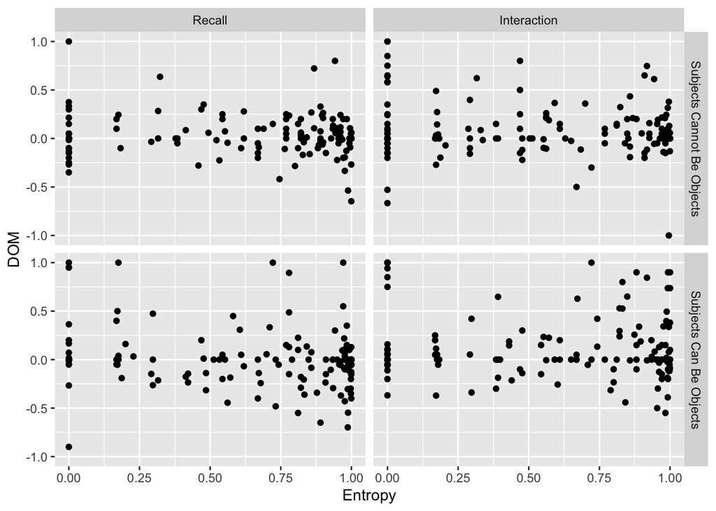

```r
#and plot
ggplot(entropy.dom,aes(x=Entropy,y=DOM)) +
  facet_grid(EventType~Block) +
  geom_point()
```

Appropriate stat? Result suggests no significant effect of word order variability on casemarking in either block.

```r
summary(lmer(DOM~Entropy * Block * EventType + (1 | workerId), data=entropy.dom))
```

```
## Linear mixed model fit by REML ['lmerMod']
## Formula: DOM ~ Entropy * Block * EventType + (1 | workerId)
##    Data: entropy.dom
##
## REML criterion at convergence: 65.6
##
## Scaled residuals:
##     Min      1Q  Median      3Q     Max
## -2.8038 -0.3993 -0.0207  0.3622  3.3322
##
## Random effects:
##  Groups   Name        Variance Std.Dev.
##  workerId (Intercept) 0.05084  0.2255
##  Residual             0.02891  0.1700
## Number of obs: 612, groups:  workerId, 312
##
## Fixed effects:
##                                     Estimate Std. Error t value
## (Intercept)                          0.04629    0.02610   1.773
## Entropy                             -0.05316    0.03645  -1.458
## BlockInteraction                     0.05879    0.02412   2.438
## EventType1                           0.02660    0.05221   0.510
## Entropy:BlockInteraction             0.03973    0.03598   1.104
## Entropy:EventType1                  -0.07193    0.07290  -0.987
## BlockInteraction:EventType1         -0.01625    0.04823  -0.337
## Entropy:BlockInteraction:EventType1  0.11491    0.07195   1.597
##
## Correlation of Fixed Effects:
##             (Intr) Entrpy BlckIn EvntT1 Ent:BI En:ET1 BI:ET1
## Entropy     -0.786
## BlckIntrctn -0.522  0.463
## EventType1   0.069 -0.051 -0.056
## Entrpy:BlcI  0.405 -0.509 -0.816  0.052
## Entrpy:EvT1 -0.051  0.021  0.047 -0.786 -0.041
## BlckInt:ET1 -0.056  0.047  0.093 -0.522 -0.068  0.463
## Entr:BI:ET1  0.052 -0.041 -0.068  0.405  0.029 -0.509 -0.816
```

Same stat excluding 0-word-order-entropy individuals.

```r
summary(lmer(DOM~Entropy * Block * EventType + (1 | workerId), data=subset(entropy.dom,Entropy>0)))
```

```
## Linear mixed model fit by REML ['lmerMod']
## Formula: DOM ~ Entropy * Block * EventType + (1 | workerId)
##    Data: subset(entropy.dom, Entropy > 0)
##
## REML criterion at convergence: 30.9
##
## Scaled residuals:
##      Min       1Q   Median       3Q      Max
## -2.73686 -0.43091 -0.02674  0.37998  2.87254
##
## Random effects:
##  Groups   Name        Variance Std.Dev.
##  workerId (Intercept) 0.04145  0.2036
##  Residual             0.02974  0.1724
## Number of obs: 446, groups:  workerId, 244
##
## Fixed effects:
##                                      Estimate Std. Error t value
## (Intercept)                          0.056272   0.053011   1.062
## Entropy                             -0.065438   0.065430  -1.000
## BlockInteraction                     0.009928   0.057984   0.171
## EventType1                          -0.042391   0.106021  -0.400
## Entropy:BlockInteraction             0.096922   0.072106   1.344
## Entropy:EventType1                  -0.012176   0.130860  -0.093
## BlockInteraction:EventType1          0.038904   0.115968   0.335
## Entropy:BlockInteraction:EventType1  0.055275   0.144213   0.383
##
## Correlation of Fixed Effects:
##             (Intr) Entrpy BlckIn EvntT1 Ent:BI En:ET1 BI:ET1
## Entropy     -0.943
## BlckIntrctn -0.684  0.667
## EventType1  -0.252  0.246  0.156
## Entrpy:BlcI  0.638 -0.667 -0.956 -0.142
## Entrpy:EvT1  0.246 -0.245 -0.152 -0.943  0.139
## BlckInt:ET1  0.156 -0.152 -0.043 -0.684  0.044  0.667
## Entr:BI:ET1 -0.142  0.139  0.044  0.638 -0.050 -0.667 -0.956
```

## Word order variability and casemarking overall

Do participants who vary word order more (i.e. word order is less informative about argument structure) casemark more, irrespective of animacy?

Measure of word order variability: entropy.

Measure of casemarking: % marked objects.

Will look at day 4 and contrast recall and interaction.

```r
#for casemarking on day 4, use recall.vs.interaction.summary
#merge
entropy.marking <- merge(proportion.sov,recall.vs.interaction.summary,
                               by=c("workerId","EventType","Block"))
```

Looks strikingly like no correspondence in either case.

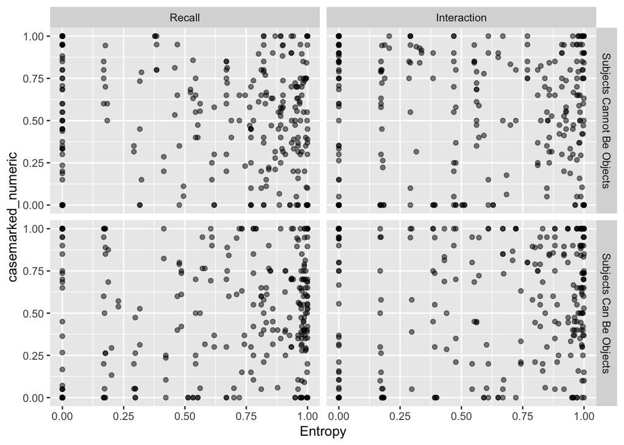

```r
#and plot
ggplot(entropy.marking,aes(x=Entropy,y=casemarked_numeric)) +
  facet_grid(EventType~Block) +
  geom_point(alpha=0.5)
```

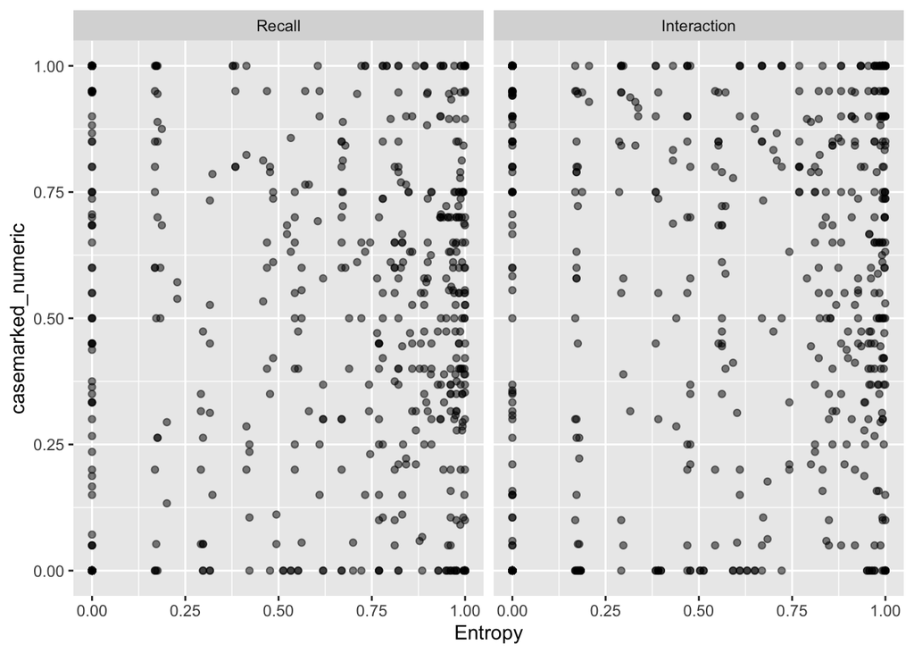

```r
#and plot
ggplot(entropy.marking,aes(x=Entropy,y=casemarked_numeric)) +
  facet_grid(~Block) +
  geom_point(alpha=0.5)
```

Appropriate stat? Result suggests no significant effect of word order variability on casemarking in either Block.

```r
contrasts(entropy.marking$EventType) <- c(-0.5,0.5)
summary(lmer(casemarked_numeric~Entropy * Block * EventType + (1 | workerId), data=entropy.marking))
```

```
## Linear mixed model fit by REML ['lmerMod']
## Formula: casemarked_numeric ~ Entropy * Block * EventType + (1 | workerId)
##    Data: entropy.marking
##
## REML criterion at convergence: 370.3
##
## Scaled residuals:
##     Min      1Q  Median      3Q     Max
## -3.0045 -0.4905 -0.0135  0.4999  3.3055
##
## Random effects:
##  Groups   Name        Variance Std.Dev.
##  workerId (Intercept) 0.08872  0.2979
##  Residual             0.04420  0.2102
## Number of obs: 1230, groups:  workerId, 314
##
## Fixed effects:
##                                      Estimate Std. Error t value
## (Intercept)                          0.456459   0.028083  16.254
## Entropy                              0.040247   0.037210   1.082
## BlockInteraction                     0.076283   0.021069   3.621
## EventType1                           0.056628   0.056167   1.008
## Entropy:BlockInteraction             0.009415   0.031546   0.298
## Entropy:EventType1                  -0.076404   0.074419  -1.027
## BlockInteraction:EventType1         -0.047985   0.042137  -1.139
## Entropy:BlockInteraction:EventType1  0.075445   0.063092   1.196
##
## Correlation of Fixed Effects:
##             (Intr) Entrpy BlckIn EvntT1 Ent:BI En:ET1 BI:ET1
## Entropy     -0.739
## BlckIntrctn -0.437  0.415
## EventType1   0.054 -0.038 -0.050
## Entrpy:BlcI  0.329 -0.438 -0.816  0.049
## Entrpy:EvT1 -0.038  0.008  0.043 -0.739 -0.043
## BlckInt:ET1 -0.050  0.043  0.098 -0.437 -0.072  0.415
## Entr:BI:ET1  0.049 -0.043 -0.072  0.329  0.032 -0.438 -0.816
```

Same stat excluding 0-word-order-entropy individuals.

```r
summary(lmer(casemarked_numeric~Entropy * Block * EventType + (1 | workerId), data=subset(entropy.marking,Entropy>0)))
```

```
## Linear mixed model fit by REML ['lmerMod']
## Formula: casemarked_numeric ~ Entropy * Block * EventType + (1 | workerId)
##    Data: subset(entropy.marking, Entropy > 0)
##
## REML criterion at convergence: 160.4
##
## Scaled residuals:
##     Min      1Q  Median      3Q     Max
## -3.1787 -0.5290 -0.0136  0.5435  2.7131
##
## Random effects:
##  Groups   Name        Variance Std.Dev.
##  workerId (Intercept) 0.07118  0.2668
##  Residual             0.03911  0.1978
## Number of obs: 893, groups:  workerId, 245
##
## Fixed effects:
##                                     Estimate Std. Error t value
## (Intercept)                          0.55015    0.05175  10.630
## Entropy                             -0.06920    0.06285  -1.101
## BlockInteraction                     0.01954    0.05004   0.390
## EventType1                          -0.10584    0.10351  -1.022
## Entropy:BlockInteraction             0.07055    0.06175   1.143
## Entropy:EventType1                   0.12952    0.12569   1.030
## BlockInteraction:EventType1          0.04903    0.10008   0.490
## Entropy:BlockInteraction:EventType1 -0.03726    0.12350  -0.302
##
## Correlation of Fixed Effects:
##             (Intr) Entrpy BlckIn EvntT1 Ent:BI En:ET1 BI:ET1
## Entropy     -0.925
## BlckIntrctn -0.648  0.649
## EventType1  -0.254  0.254  0.146
## Entrpy:BlcI  0.601 -0.637 -0.960 -0.129
## Entrpy:EvT1  0.254 -0.259 -0.146 -0.925  0.129
## BlckInt:ET1  0.146 -0.146 -0.020 -0.648  0.019  0.649
## Entr:BI:ET1 -0.129  0.129  0.019  0.601 -0.025 -0.637 -0.960
```